# Pandas Tutorial

###### Merge DataFrames on Columns

```python
# Sometimes it is required to specify the column names you wanted to merge, to do so use on param.
# For example
# df3=pd.merge(df1,df2, on='Courses').
# this will result on same output as above
```

###### Merging DataFrames on Multiple Columns

Use param on with a list of column names when you wanted to merge DataFrames by multiple columns. It also supports different column names on the left and right DataFrames, below is an example

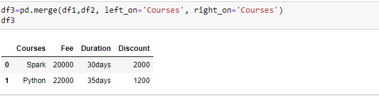

###### Merging Using Different Join Types

In the below dataframes doing the different joins

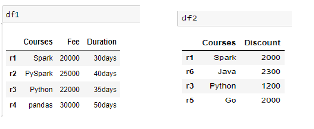

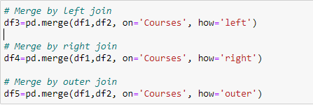

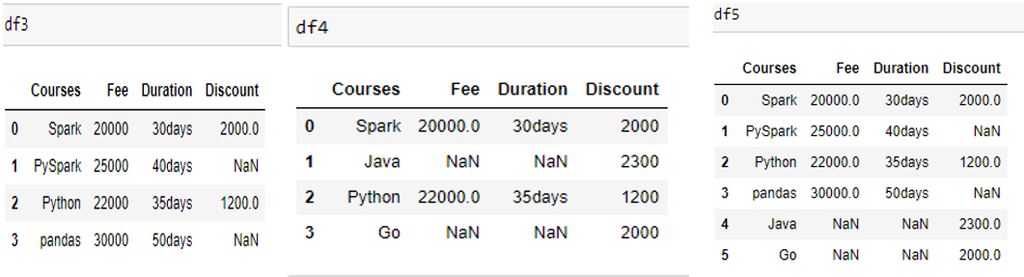

```python
# note
# --Left join-eft Outer Join that returns all rows from the left DataFrame regardless of match found on the right DataFrame.
# When the join expression doesn’t match, it assigns null for that record and drops records from right where match not found.
# --Right Join-returns all rows from the right DataFrame regardless of math found on the left. When the join expression
# doesn’t match, it assigns null for that record and drops records from left where match not found.
# --Outer Join -Returns all rows from both DataFrames. Where join expression doesn’t match it returns null on respective cells
```

##### Concat

Concatenating is the process of joining two or more DataFrames either vertically or horizontally. In pandas, this can be achieved using the concat() function. The concat() function allows you to combine two or more DataFrames into a single DataFrame by stacking them either vertically or horizontally.

###### pandas concat() Syntax and Usage

```python
pandas.concat(objs, axis=0, join='outer', ignore_index=False, keys=None, levels=None,
              names=None, verify_integrity=False, sort=False, copy=True)
```

###### Use pandas.concat() to Concat Two DataFrames

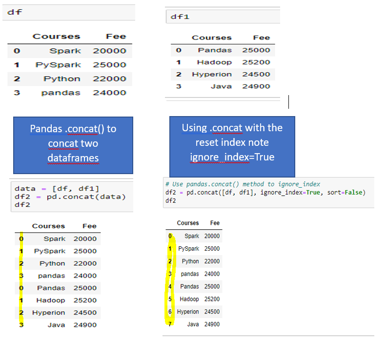

###### Using pandas.concat() to Join Two DataFrames

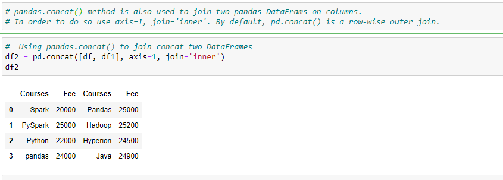

###### Use DataFrame.append() to Concat Two DataFrames

we can use pandas.DataFrame.append() method to concatenate DataFrames on rows. For E.x, df.append(df1) appends df1 to the df DataFrame. Use ignore_index=True param to reset the index on combined DataFrame

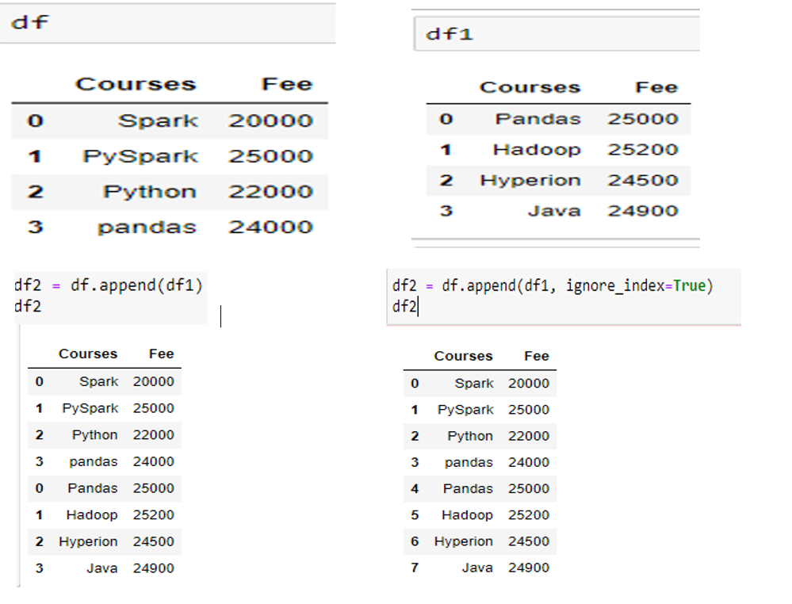

```python
# Joining is a method of combining two DataFrames into one based on their index or column values.

# There are four types of joins in pandas: inner, outer, left, and right.

# Inner Join: Returns only the rows that have matching index or column values in both DataFrames.
# Outer Join: Returns all the rows from both DataFrames and fills in the missing values with NaN where there is no match.
# Left Join: Returns all the rows from the left DataFrame and the matching rows from the right DataFrame.
#Fills in the missing values with NaN where there is no match.
# Right Join: Returns all the rows from the right DataFrame and the matching rows from the left DataFrame.
#Fills in the missing values with NaN where there is no match.
```

###### Differences

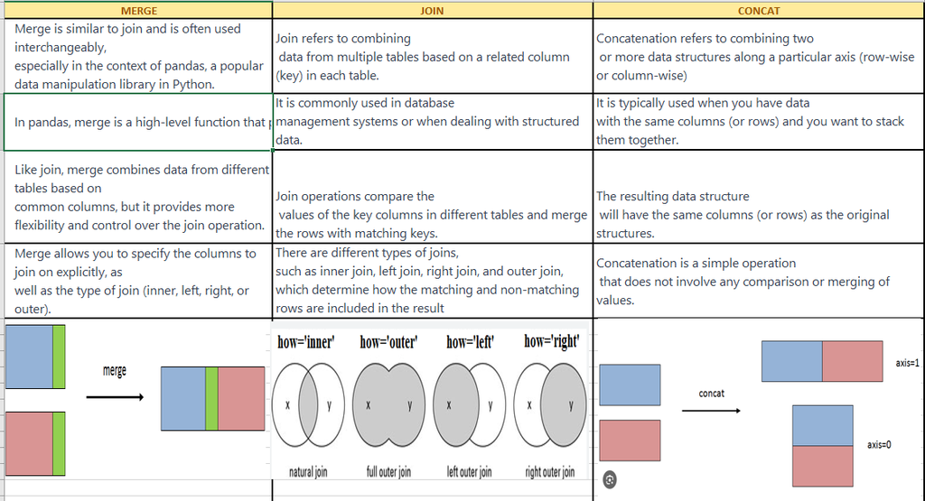

#### 8.Comparison with SQl

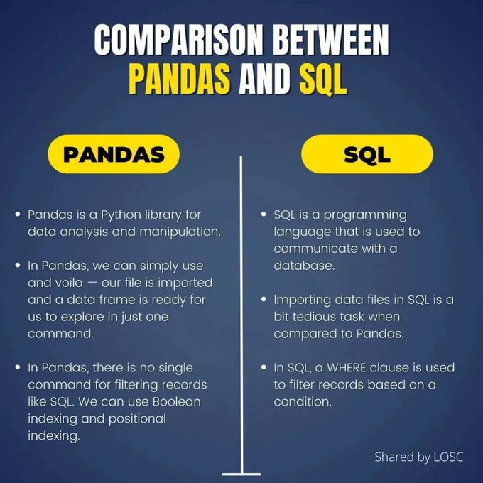